# Modelli a componenti non osservabili (UCM: Unobserved Component Models)

## Componente ciclica

Il ciclo stocastico può essere utilizzato come componente a sè per normalizzare il ciclo economico o come parte con certe frequenze permette di normalizzare la stagionalità.

Viene generato da una funzione sinusoidale ed è generato da un vettore di dimensione 2 (ai fini della previsione è indifferente prendere $\psi_t \space o \space \psi_t^*$:

$$\left( \begin{array}{cc} \psi_t \\ \psi_t^* \end{array} \right) = \rho \space \left( \begin{array}{cc} \cos \lambda & \sin \lambda \\ -\sin \lambda & \cos \lambda \end{array} \right) \left( \begin{array}{cc}\psi_{t-1} \\ \psi_{t-1}^* \end{array} \right) + \left( \begin{array}{cc} k_t \\ k_t^* \end{array} \right)$$
Dove:

$\rho$ è un fattore di smorzamento.

$R(\lambda)=\left( \begin{array}{cc} \cos \lambda & \sin \lambda \\ -\sin \lambda & \cos \lambda \end{array} \right)$ è la matrice di rotazione e $\lambda$ è la frquenza del ciclo stocastico (angolo della sinusoide).

$\left( \begin{array}{cc} k_t \\ k_t^* \end{array} \right)$ sono i rispettivi WN di $\psi_t$ e di $\psi_t^*$

Per arrivare a questa formula finale partiamo dalla definizione di una sinusoide che varia nel tempo con ampiezza R frequenza $\lambda$ e con fase $\phi$:

$$f(t) = R \cos (\phi + \lambda \space t)$$

Quindi la sinusoide dipende da 3 fattori:

La **frequenza** indica quanto velocemente la funzione ci mette a fare un giro completo, quindi più $\lambda$ è grande maggiore sarà il numero di oscillazioni in una unità di tempo. Per definire in modo più chiaro la frequenza definiamo $\lambda$ come $\lambda = \frac{2 \space \pi}{periodo}$ e il periodo è il numero di istanti temporali che ci mette la sinusoide per completare il suo ciclo.

Vediamo alcuni esempi (per adesso ipotiziamo $R=1 \space e \space \phi=0$:

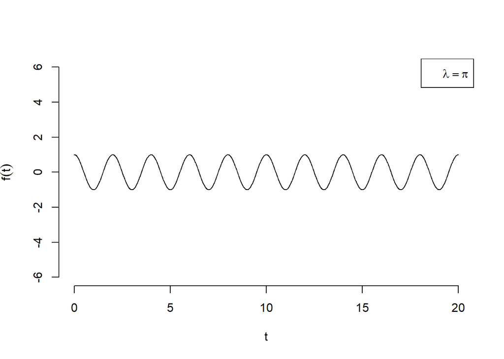

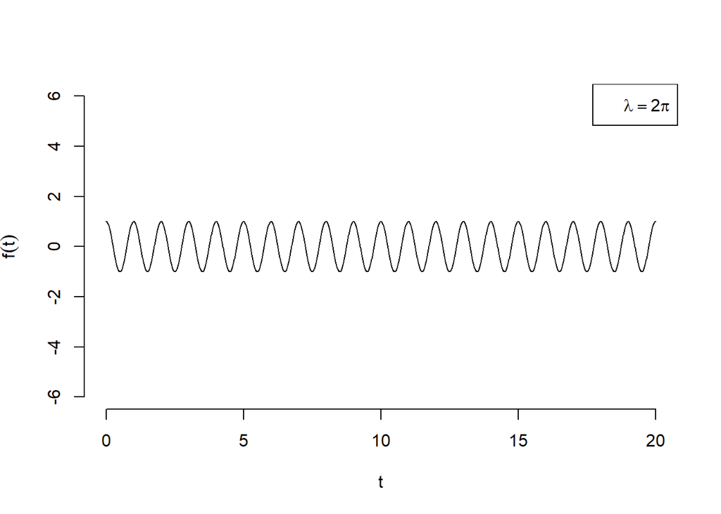

R modifica il **range di oscillazione (ampiezza)** della sinusoide:

Vediamo alcuni esempi (per adesso ipotiziamo $\lambda=\pi \space e \space \phi=0$:

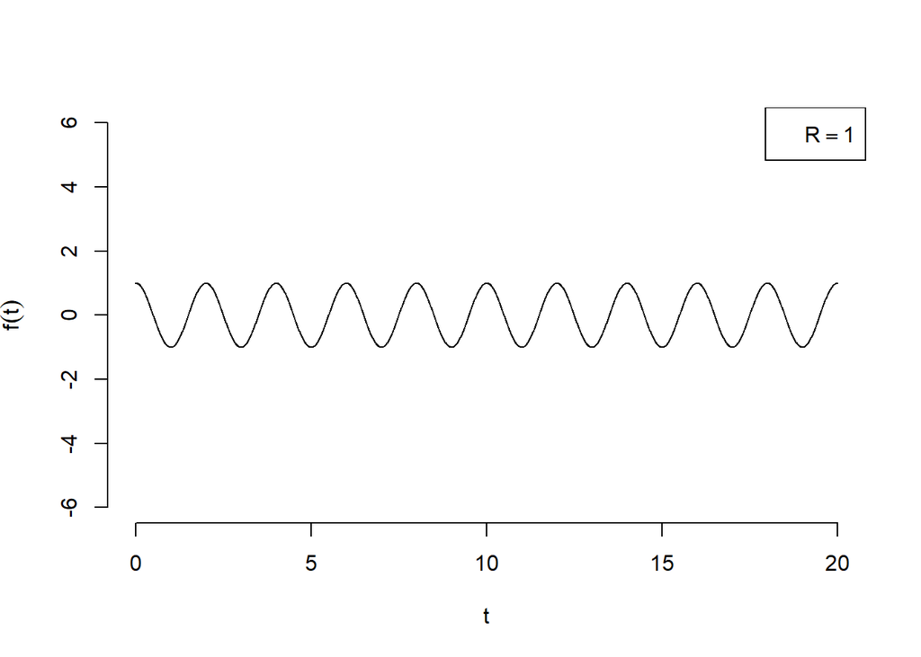

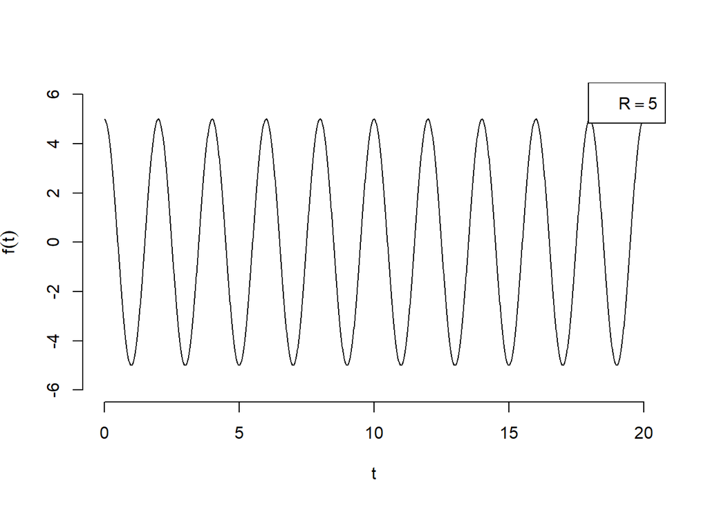

Infine la **fase** modifica il punto da cui parte il coseno, quindi sposta il grafico di una quantità pari a $-\phi/\lambda$.

Vediamo alcuni esempi (per adesso ipotiziamo $R=1 \space e \space \lambda=\pi$:

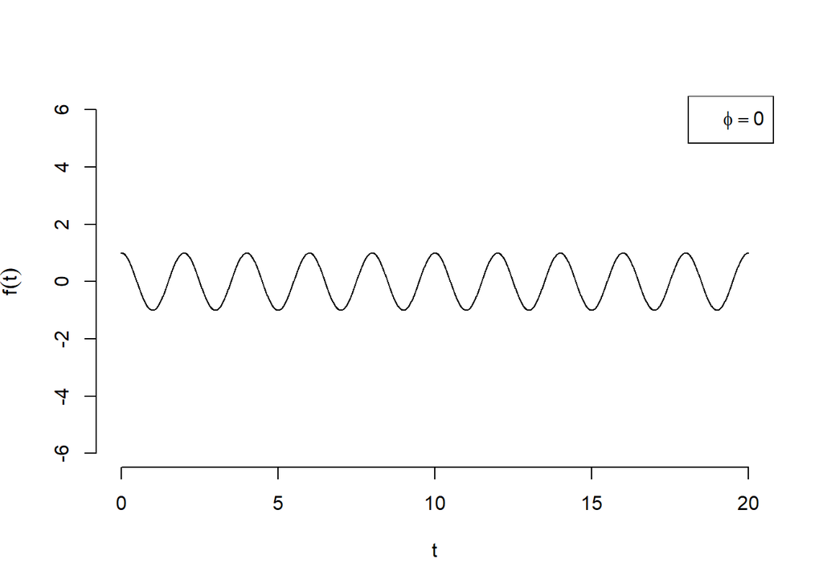

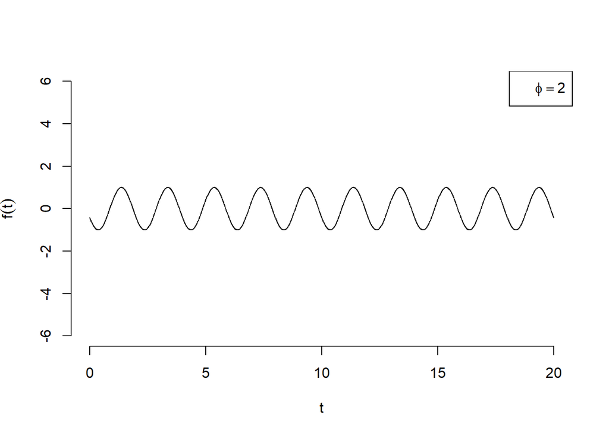

Questa forma funzionale è molto utile per capire l’utilità di ogni singolo parametro ma dato che $\phi \space e \space \lambda$ sono all’interno del coseno nel calcolo dei regressori sarebbe necessario minimizzare i quadrati in modo non lineare, per questo spesso si utilizza un’altra scrittura della sinusoide che è equivalente:

$$f(t) = R \cos(\phi + \lambda \space t) = \\ = R \cos(\phi) \cos(\lambda \space t) - R \sin(\phi) \sin(\lambda \space t) = \\ = A \cos(\lambda \space t) + B \sin ( \lambda \space t)$$

In questo modo considerando $\cos(\lambda \space t) \space e \space \sin ( \lambda \space t)$ come due regressori A e B si possono stimare con i minimi quadrati ordinari. Faciendo lo Stesso ragionamento fatto sopra con il coseno per il seno della sinusoide troviamo la matrice di rotazione.

La matrice, quindi, $R(\lambda)$ è una matrice quadrata ortogonale di rango 2 che permette la rotazione in senso orario in un piano di 2 dimensioni di un angolo $\lambda$ intorno all’origine.

Infine andiamo ad analizzare l’utilità del parametro presente nella formula iniziale $\rho$. Andiamo ad analizzare le situazioni possibili e i possibili risultati:

- $\rho=0 \Rightarrow$ implica che $\psi_t \sim WN$;
- $\rho=1 \Rightarrow$ ciclo non stazionario;
- $0 < \rho<1 \Rightarrow$ il ciclo economico ha una oscillazione di medio-breve termine (solitamente situazione più plausibile) e $\rho$ serve per rendere il ciclo stazionario dove i primi due modenti sono:
  $$E(\psi_t)=0$$
  $$Var(\psi_t)=E(\psi_t \psi_t^T) = \frac{\sigma_k^2}{1- \rho^2} I_2$$

Andiamo a fare un esempio con un modello strutturato come segue:

$$Y_t= \mu_t+\psi_t + \epsilon_t \\.\\
Dove: \\
\mu_t = \mu_{t-1}+\beta+ \eta_t \space \space con \space \space \eta_t \sim WN(0, \sigma^2_{\eta})\\
\left( \begin{array}{cc} \psi_t \\ \psi_t^* \end{array} \right) = \rho \space \left( \begin{array}{cc} \cos \lambda & \sin \lambda \\ -\sin \lambda & \cos \lambda \end{array} \right) \left( \begin{array}{cc}\psi_{t-1} \\ \psi_{t-1}^* \end{array} \right) + \left( \begin{array}{cc} k_t \\ k_t^* \end{array} \right) \space \space con \space \space \left( \begin{array}{cc} k_t \\ k_t^* \end{array} \right) \sim WN(\underline{0}, \sigma_k^2 \space I_2) \\
\epsilon_t = WN(0, \sigma^2_{\epsilon})$$

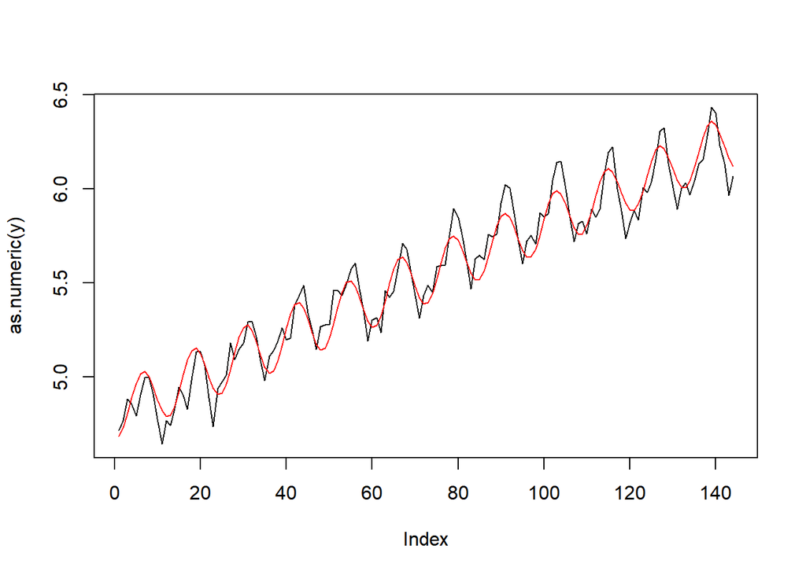

```r
y<-log(AirPassengers)
trend<-1:144

R=1 # da adesso lo chiameremo rho pewrche R chiamiamo la funzione di rotazione
rho=1
phi=0
periodo=12
lambda=2*pi/periodo
x=seq(1,length(AirPassengers),1)
ciclo<- matrix(c(0,1),2,144)

#Creiamo la funzione di rotazione
R = function ( lambda ){
  co = cos(lambda)
  si = sin(lambda)
  matrix(c(co,-si,si,co),2,2)
}


sig_kappa=0.01
for ( t in 2:n){
  ciclo[,t]=rho*R(lambda) %*% ciclo[,t-1]+rnorm(2,sd=sig_kappa)
}



#per cicli di ordine superiore usare:
# esempio ciclo di ordine 2
#for ( t in 2:n){
#  ciclo1[,t]=rho*R(lambda) %*% ciclo1[,t-1]+rnorm(2,sd=sig_kappa)
#  ciclo2[,t]=rho*R(lambda) %*% ciclo2[,t-1]+ciclo1[,t-1]  #ciclo di ordine superiore
#}


reg4<-lm(y~trend+ciclo[1,]+ciclo[2,])


#vediamo come sarebbe il nostro fit:
plot(as.numeric(y), type="l")
lines(reg4$fitted.values, col="red")
```

```r
summary(reg4)
```

```
##
## Call:
## lm(formula = y ~ trend + ciclo[1, ] + ciclo[2, ])
##
## Residuals:
##       Min        1Q    Median        3Q       Max
## -0.261856 -0.065582  0.001491  0.068906  0.177989
##
## Coefficients:
##               Estimate Std. Error t value Pr(>|t|)
## (Intercept)  4.8147793  0.0150975 318.911  < 2e-16 ***
## trend        0.0100303  0.0001807  55.493  < 2e-16 ***
## ciclo[1, ]   0.0350801  0.0102077   3.437 0.000776 ***
## ciclo[2, ]  -0.1392321  0.0101752 -13.683  < 2e-16 ***
## ---
## Signif. codes:  0 '***' 0.001 '**' 0.01 '*' 0.05 '.' 0.1 ' ' 1
##
## Residual standard error: 0.08996 on 140 degrees of freedom
## Multiple R-squared:  0.9593, Adjusted R-squared:  0.9585
## F-statistic:  1101 on 3 and 140 DF,  p-value: < 2.2e-16
```

# Example finale

In questo esempio finale mettiamo insieme tutte le componenti per creare un modello UCM completo.

$$Y_t= \mu_t+\gamma_t+\psi_t + \epsilon_t \\.\\
Dove: \\
\mu_t = \mu_{t-1}+\beta+ \eta_t \space \space con \space \space \eta_t \sim WN(0, \sigma^2_{\eta})\\
\gamma_t = -\gamma_{t-1}-\gamma_{t-2}-...-\gamma_{t-(s-1)} + \omega_t \space \space con \space \space \omega_t \sim WN(0, \sigma^2_{\omega}) \\
\left( \begin{array}{cc} \psi_t \\ \psi_t^* \end{array} \right) = \rho \space \left( \begin{array}{cc} \cos \lambda & \sin \lambda \\ -\sin \lambda & \cos \lambda \end{array} \right) \left( \begin{array}{cc}\psi_{t-1} \\ \psi_{t-1}^* \end{array} \right) + \left( \begin{array}{cc} k_t \\ k_t^* \end{array} \right) \space \space con \space \space \left( \begin{array}{cc} k_t \\ k_t^* \end{array} \right) \sim WN(\underline{0}, \sigma_k^2 \space I_2) \\
\epsilon_t = WN(0, \sigma^2_{\epsilon})$$

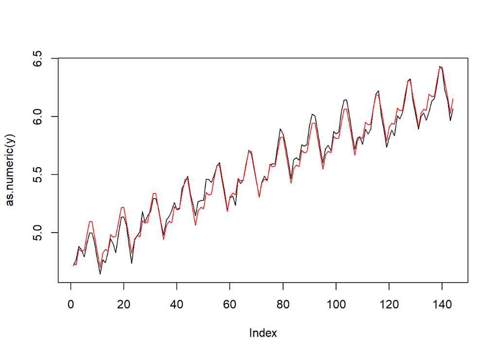

```r
mesi<-c("gen","feb","mar","apr","magg","giugno","lugl","ago","sett","ott","nov","dec")
mesi<-factor(rep(mesi,(1960-1949)+1),levels = c("gen","feb","mar","apr","magg","giugno","lugl","ago","sett","ott","nov","dec"))



R=1
phi=0
periodo=12
lambda=2*pi/periodo
x=seq(1,length(AirPassengers),1)
ciclo<-R*cos(phi+(lambda*x))


reg_tot<-lm(y~trend+ciclo+mesi)


#vediamo come sarebbe il nostro fit:
plot(as.numeric(y), type="l")
lines(reg_tot$fitted.values, col="red")
```

```r
summary(reg_tot)
```

```
##
## Call:
## lm(formula = y ~ trend + ciclo + mesi)
##
## Residuals:
##       Min        1Q    Median        3Q       Max
## -0.156370 -0.041016  0.003677  0.044069  0.132324
##
## Coefficients: (1 not defined because of singularities)
##               Estimate Std. Error t value Pr(>|t|)
## (Intercept)  4.8646019  0.1690396  28.778  < 2e-16 ***
## trend        0.0100688  0.0001193  84.399  < 2e-16 ***
## ciclo       -0.1591426  0.1809755  -0.879    0.381
## mesifeb     -0.0803051  0.0810948  -0.990    0.324
## mesimar     -0.0296492  0.1701273  -0.174    0.862
## mesiapr     -0.1404894  0.2601704  -0.540    0.590
## mesimagg    -0.2011123  0.3262466  -0.616    0.539
## mesigiugno  -0.1002871  0.3504524  -0.286    0.775
## mesilugl     0.0249763  0.3262594   0.077    0.939
## mesiago      0.0739317  0.2601961   0.284    0.777
## mesisett     0.0088684  0.1701655   0.052    0.959
## mesiott     -0.0497186  0.0811440  -0.613    0.541
## mesinov     -0.1351861  0.0242400  -5.577 1.34e-07 ***
## mesidec             NA         NA      NA       NA
## ---
## Signif. codes:  0 '***' 0.001 '**' 0.01 '*' 0.05 '.' 0.1 ' ' 1
##
## Residual standard error: 0.0593 on 131 degrees of freedom
## Multiple R-squared:  0.9835, Adjusted R-squared:  0.982
## F-statistic: 649.4 on 12 and 131 DF,  p-value: < 2.2e-16
```

# Regressori nei modelli UCM

Regressore (o variabile esplicativa), in statistica, è il termine con cui si indica ognuna delle variabili indipendenti che si individuano come variabili significative per spiegare un fenomeno in un modello.

$$Y_t= \mu_t+\gamma_t+\psi_t + \underline{\delta}_t^T \space \underline{X}_t + \epsilon_t$$

Non è necessario avere una relazione di Cointegration tra $Y_t$ e $X_t$ e possiamo inserirli nelle equazioni delle componenti non osservabili.

## Regressori statici

Spesso le serie storiche presentano cambiamenti repentini e se ne possono considerare quattro tipi:

**1. Outlier additivo (AO)**: in una certa data la serie storica assume un valore molto diverso dagli altri ma dalla data successiva torna a seguire l’andamento che aveva precedentemente (ad es. un evento che dura solo un giorno se la serie è giornaliera).
$$AO_t = \begin{cases} 1, & \mbox{if } \space t=t_0 \\ 0, & \mbox{if } \space t \ne t_0 \end{cases}$$

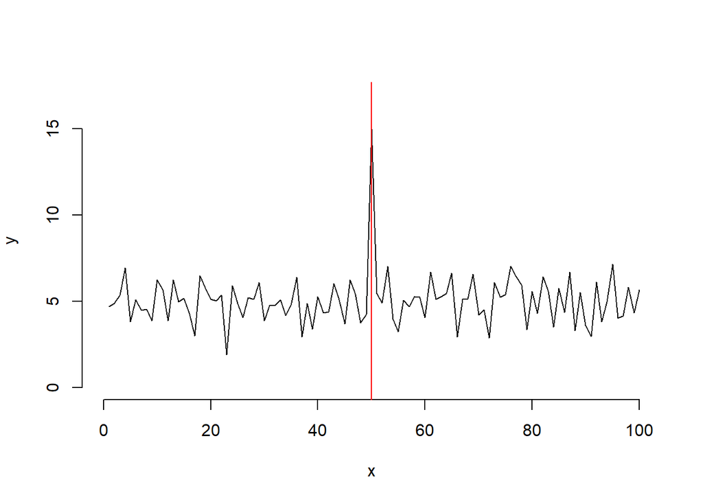

**2. Temporary change (TC)**: avviene su una serie di date successive (potrebbe essere dovuto ad un evento che dura più di un giorno ma poi si esaurisce).
$$TC_t = \begin{cases} 1, & \mbox{if } \space t_0 \le t \le t_1 \\ 0, & \space altrimenti \end{cases}$$

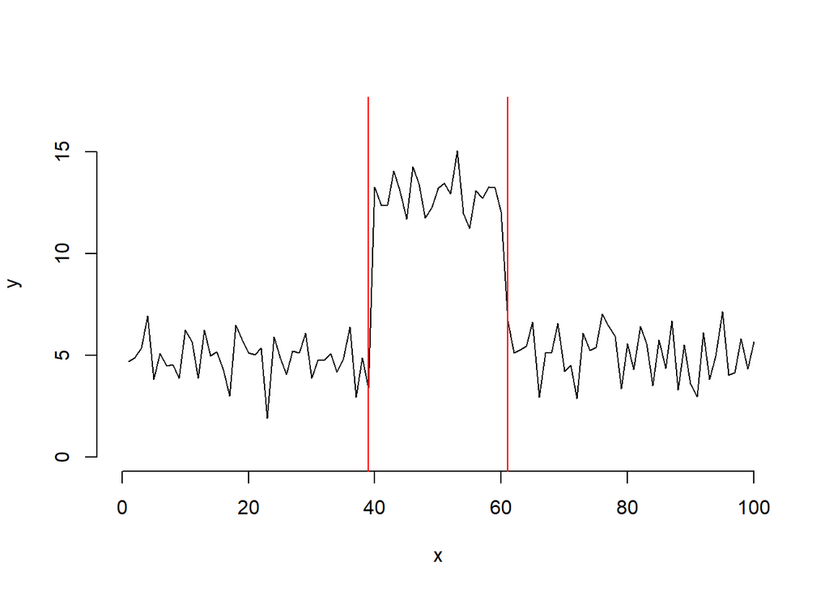

**3. Level shift (LS)**: avviene un cambio di livello definitivo (variabile scalino)
$$LS_t = \begin{cases} 1, & \mbox{if } \space t\ge t_0 \\ 0, & \mbox{if } \space t < t_0 \end{cases}$$

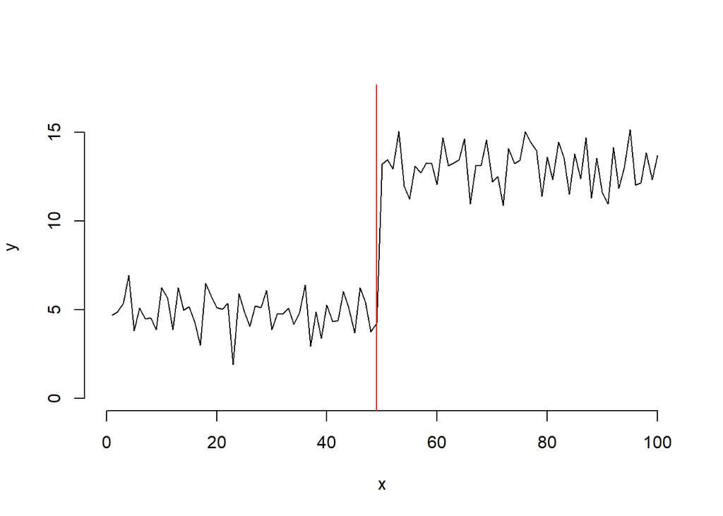

**4. Slope shift (SS)**: cambio di pendenza permanente della serie stori
$$SS_t = \begin{cases} t-t_0+1, & \mbox{if } \space t\ge t_0 \\ 0, & \mbox{if } \space t < t_0 \end{cases}$$

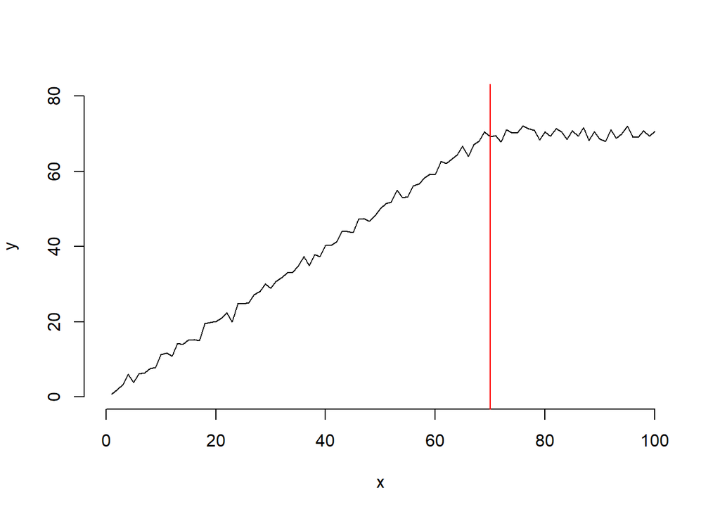

Questo modello presuppone che $X$ al tempo $t$ abbia effetto solo su $Y$ al tempo $t$ e che il suo effetto sia nullo nei tempi successivi. Si tratta di una situazione riduttiva perché ad es. un investimento in pubblicità ha sia effetti immediati che duraturi, anche se si affievoliscono nel tempo.

## Regressori dinamici

Il modello con i regressori statici presuppone che $X$ al tempo $t$ abbia effetto solo su $Y$ al tempo $t$ e che il suo effetto sia nullo nei tempi successivi. Si tratta di una situazione riduttiva perché ad es. un investimento in pubblicità ha sia effetti immediati che duraturi, anche se si affievoliscono nel tempo. Potrebbe quindi essere utile introdurre dei ritardi.

$$Y_t= \space ... + \delta_0^T X_t + \delta_1^T X_{t-1} + \delta_2^T X_{t-2} + \space ...$$

### Problematicità

Il problema di questo metodo è che se l’effetto è molto lungo si devono considerare molti regressori e stimare molti coefficienti di regressione, quindi si perdono altrettanti gradi di libertà (le stime dei coefficienti non saranno precise perché il numero di osservazioni per coefficiente diventa troppo basso). Inoltre se si avesse un effetto di $X_t$ permanente non sarebbe possibile inserire infiniti regressori nel modello perché con un numero finito di dati non si possono stimare infiniti coefficienti.

### Regressione dinamica (funzione di trasferimento):

Per ovviare a questi problemi si utilizza può utilizzare in questi casi un modello simile a quello dei modelli ARIMA dove la parte MA è responsabile di movimenti autodipendenti di breve periodo e la parte AR è responsabile dei movimenti di lungo periodo.

$$Y_t= \space ... + \delta_1^T Y_{t-1} + ... + \delta_r^T Y_{t-r} + \omega_0^T X_{t} + \omega_1^T X_{t-1} + ... + \omega_s^T X_{t-s} + \space ...$$

Un modello che si utilizza spesso per misurare l'effetto di una campagna pubblicitaria è con r=1 e s=0:

$$Y_t= \delta_1^T Y_{t-1} + \omega_0^T X_{t}$$

In questo modello la funzione di risposta all'impulso risulta essere decrescente ossia permette di modellare una campagna publlicitaria in quanto con $\delta_1^T Y_{t-1}$, la componente AR, modelliamo l'effetto di lungo periodo in quale si affievolisce pian piano mentre con $\omega_0^T X_{t}$, la componente (pseudo-)MA, modeliamo la componente di breve periodo della campagna publicitaria.